# ROOT Analysis

Today I will outline some of the basics in root. These will not be accessible in jupyter so once your Jlab accounts are setup you can access this.

1. ROOT basics
2. ROOT in python
3. Excercise

## ROOT basics

In the jlab terminal start root with

> user@login.jlab.org> root

This will take you into a root subsystem where you can perform ROOT based commands. There are many commands you can perform such as plotting and manipulating the data, but we will only be interested in one command. Feel free to research more if you're curious.

The command we are interested in is called *TBrowser* which will show us all the histograms inside the ROOT file.

> root>new TBrowser

## ROOT in python

Since you are more familiar with python we will continue analysis there. We use a python package called uproot (so make sure to pip this).

```python
# Import uproot package
import uproot as up
rootName="jnb_files/pid_coin_offline_7978_50000.root"
# Read in ROOT file. We call a group of histograms the tree and each histogram the branch or leaf.
# In this case we open the tree called "T"
tree = up.open(rootName)["T"]

# We are grabbing two histograms, one defining the energy of the missing mass and the other the momentum
emiss = tree.array("P.kin.secondary.emiss")
pmiss = tree.array("P.kin.secondary.pmiss")
```

```python
import numpy as np
# We can define the actual missing mass using the Einstein mass-energy equation
missmass = np.array(np.sqrt(abs(emiss*emiss-pmiss*pmiss)))
```

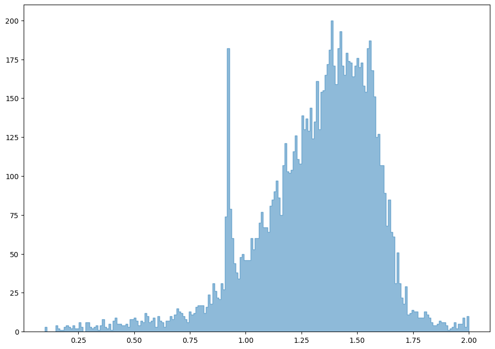

```python
# We will then plot a simple histogram of the missing mass plot
import matplotlib.pyplot as plt
f = plt.figure(figsize=(11.69,8.27))
plt.style.use('default')

# When we define our histogram we can make a finer binning or more coarse binning with the "bins" flag
# We also define a range because the missing mass will only be in a certain range of the the histogram space
plt.hist(missmass,bins=200,range=(0.1,2.0),label='pi cut',histtype='step', alpha=0.5, stacked=True, fill=True)
```

Now this is missing mass spectrum for all the particles in the spectrometers. We only want to isolate one particle, protons or $\Lambda$s. This means we need to add cuts!

## Exercise 3

You will need the above ROOT file. I will send it in a separate email since it is too large to add to GitHub.

This one may be challenging. I want you to add a cut to the above plot. Eventually we will want a few cuts, so for now just worry about one cut. We will start simple by trying to isolate the proton events.

Of course, if you need help you may ask Tanja or I. Think like a physicist, use the resources you have! It's all there!